# Some ancillary functions in package 'ipv'

F. Tusell

2020-11-04

## Data

```r
library(ipv)
library(rgdal)
library(rgeos)
library(tidyverse, verbose=FALSE)
data("venta.dep")
data("alquiler.dep")
```

(*Beware*: if you are using a publicly available version of this package, such data may have been obscured, distorted and shuffled to preserve confidentiality. You will not be able to reproduce the results in this vignette, although the data provided will suffice to test the use of functions.)

## Ancillary functions

The package contains some ancillary functions which are not meant to be called directly by the user(`pols` and `CompFechas`) and one (`cloromap`) which affords easy representation of a variable onto the map of the CAPV (Autonomous Community of the Basque Country) or parts of it.

### cloromap

Tomemos las observaciones de inmuebles a la venta y contabilicemos el número de ellas que existen por cada área funcional (codificada en la variable `AF`): Let+s take the observations corresponding to houses for sale and count the number in each "functional are" (coded in variable `AF`):

```r
Obs <- venta.dep %>%
  group_by(AF) %>%
  summarise( Obs= n() ) %>%
  as.data.frame()
```

The `Obs` data frame has the following structure:

```r
head(Obs)
```

```
##                         AF    Obs
## 1            Álava Central  28448
## 2        Balmaseda - Zalla   3282
## 3      Beasain - Zumarraga   2205
## 4     Bilbao Metropolitano 135390
## 5 Donostia - San Sebastián  44902
## 6                  Durango   3495
```

In order to represent these numbers on a map, we need an spatial dataframe (spframe) with polygons for the spatial entities concerned (here, functional areas, as defined in `AF`). We can obtain these polygons as follows:

```r
dsn <- system.file("extdata/CB_AREAS_FUNCIONALES_5000_ETRS89.shp",
                   package = "ipv")[1]
af  <- readOGR(dsn)
```

We have to check that the number and correspondence of areas in `Obs` and in `af` is consistent:

```r
af@data
```

```
##              A_FUNC_CAS           A_FUNC_EUS
## 0         ALAVA CENTRAL      ARABA ERDIALDEA
## 1       BALMASEDA-ZALLA         ENKARTAZIOAK
## 2     BEASAIN-ZUMARRAGA              GOIERRI
## 3  BILBAO METROPOLITANO BILBO METROPOLITARRA
## 4        DONOSTIA-S. S.     DONOSTIA-BETERRI
## 5               DURANGO          DURANGALDEA
## 6                 EIBAR          DEBABARRENA
## 7       GERNIKA-MARKINA BUSTURIALDEA-ARTIBAI
## 8                IGORRE              ARRATIA
## 9             LAGUARDIA      ARABAKO ERRIOXA
## 10               LLODIO                AIARA
## 11    MONDRAGON-BERGARA           DEBAGOIENA
## 12               MUNGIA               MUNGIA
## 13               TOLOSA            TOLOSERRI
## 14     ZARAUTZ-AZPEITIA          UROLA-KOSTA
```

```r
unique(Obs$AF)
```

```
##  [1] Álava Central            Balmaseda - Zalla        Beasain - Zumarraga      Bilbao Metropolitano
##  [5] Donostia - San Sebastián Durango                  Eibar                    Gernika - Markina
##  [9] Igorre                   Laguardia                Llodio                   Mondragón - Bergara
## [13] Mungia                   Tolosa                   Zarautz - Azpeitia
## 15 Levels: Álava Central Balmaseda - Zalla Beasain - Zumarraga Bilbao Metropolitano ... Zarautz - Azpeitia
```

```r
cbind(af@data$A_FUNC_CAS,
      levels(sort(unique(Obs$AF))))
```

```
##       [,1]                   [,2]
##  [1,] "ALAVA CENTRAL"        "Álava Central"
##  [2,] "BALMASEDA-ZALLA"      "Balmaseda - Zalla"
##  [3,] "BEASAIN-ZUMARRAGA"    "Beasain - Zumarraga"
##  [4,] "BILBAO METROPOLITANO" "Bilbao Metropolitano"
##  [5,] "DONOSTIA-S. S."       "Donostia - San Sebastián"
##  [6,] "DURANGO"              "Durango"
##  [7,] "EIBAR"                "Eibar"
##  [8,] "GERNIKA-MARKINA"      "Gernika - Markina"
##  [9,] "IGORRE"               "Igorre"
## [10,] "LAGUARDIA"            "Laguardia"
## [11,] "LLODIO"               "Llodio"
## [12,] "MONDRAGON-BERGARA"    "Mondragón - Bergara"
## [13,] "MUNGIA"               "Mungia"
## [14,] "TOLOSA"               "Tolosa"
## [15,] "ZARAUTZ-AZPEITIA"     "Zarautz - Azpeitia"
```

There is one-to-one correspondence. We rename the levels in `venta.dep` with the names in `af`.

```r
levels(Obs$AF) <- af@data$A_FUNC_CAS
```

Now we can invoke:

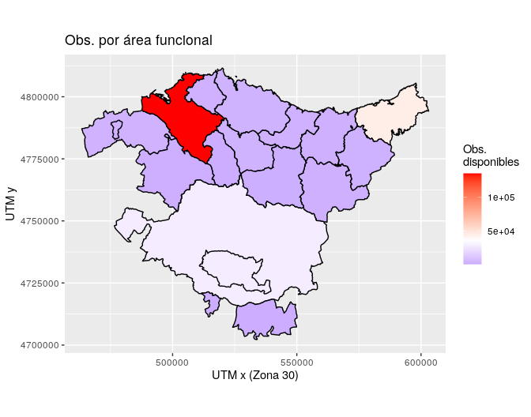

```r
cloromap(sp=af, var.sp="A_FUNC_CAS", df=Obs, var.df="AF",
         var="Obs", legend.title="Obs.\ndisponibles",
         graf.title="Obs. por área funcional",
         midpoint=36000)
```

Lo que es crucial para que lo anterior funcione es la correspondencia 1-1 entre los niveles de la variable `var.sp` de la dataframe espacial `sp` y la variable `var.df` de la dataframe ordinaria `df`. El argumento `midpoint` da el valor "neutro" (codificado con blanco en la escala cromática divergente empleada), que habitualmente querremos hacer coincidir con la mediana de los valores, pero podemos fijar a nuestro antojo.

### Fusion

Quite often the names identifying locations are not homogeneous across sources, which makes it difficult to merge information from different files. The function `Fusion` tries to simplity life a bit in such situation. It can be used in both ways, with one or two dataframes.

Whe used with one dataframe (which has to be 'X', de first argument), it scans the column named in `varX`, performs a match with the column `locX` in the translation dataframe `canon`, and overwrites `varX` with the canonical names in `canon` (or fills an NA if a match is not possible).

This sort of invocation with a single dataframe is useful to aggregate. Assume a number of areas, some of which make part of the CAPV (Basque Autonomous Community) while others do not. If we want to aggregate CAPV and Non-CAPV areas, we could construct a translation dataframe `canon` as follows:

```r
canon <- data.frame(X=c("Bilbao","San Sebastian","Vitoria","Teruel","Soria"),
                    Y=c("Bilbao","Donostia","Vitoria/Gazteiz", "Teruel","Soria"),
                    Canon=c("CAPV","CAPV","CAPV","NoCAPV","NoCAPV"))
canon
```

```
##               X               Y  Canon
## 1        Bilbao          Bilbao   CAPV
## 2 San Sebastian        Donostia   CAPV
## 3       Vitoria Vitoria/Gazteiz   CAPV
## 4        Teruel          Teruel NoCAPV
## 5         Soria           Soria NoCAPV
```

Now considera a dataframe such as:

```r
X     <- data.frame(a=c("Bilbao","San Sebastian","Vitoria","Teruel"),
                    b=c(100,70,35,12))
X
```

```
##               a   b
## 1        Bilbao 100
## 2 San Sebastian  70
## 3       Vitoria  35
## 4        Teruel  12
```

In order to reclassify observations in CAPV and Non-CAPV, we can invoke:

```r
Fusion(X, varX="a", locX=1, locCanon=3, canon=canon)
```

```
##        a   b
## 1   CAPV 100
## 2   CAPV  70
## 3   CAPV  35
## 4 NoCAPV  12
```

We may also invoke `Fusion` with two data frames, `X` and `Y`, each of them containing, among others, a variable "naming" records: these could be, for instance, names of municipalities, of streets, of districts, or neighbourhoods. For instance, besides `X` above we may have:

```r
Y     <- data.frame(e=c("Bilbao","Donostia","Vitoria/Gazteiz","Teruel","Soria"),
                    g=c("F","G","H","J","K"))
Y
```

```
##                 e g
## 1          Bilbao F
## 2        Donostia G
## 3 Vitoria/Gazteiz H
## 4          Teruel J
## 5           Soria K
```

Here the names of the communities (in column `e`) do not match those in column `a` of `X` above, although we are referring to the same entities (e.g., Donostia is the same as San Sebastian). Merging directly the two dataframes `X` and `Y` would fail, but `Fusion` may be used:

```r
Fusion(X,Y,varX="a",varY="e",locX=1, locY=2, locCanon=2, canon=canon)
```

```
##                 a   b g
## 1          Bilbao 100 F
## 2        Donostia  70 G
## 3           Soria  NA K
## 4          Teruel  12 J
## 5 Vitoria/Gazteiz  35 H
```

Above we are saying that we want to merge `X` and `Y` using the columns `a` and `e`, **after replacing their values by the canonical names in column `locCanon` of `canon`.** What this in effect does is to take the names in the dataframe `Y` as canonical. If `locCanon` is not stated, the canonical names would be taken from the column namec `Canon` in dataframe `canon`; this would not make much sense in this case:

```r
Fusion(X,Y,varX="a",varY="e",locX=1, locY=2, canon=canon)
```

```
##         a   b g
## 1    CAPV 100 F
## 2    CAPV 100 G
## 3    CAPV 100 H
## 4    CAPV  70 F
## 5    CAPV  70 G
## 6    CAPV  70 H
## 7    CAPV  35 F
## 8    CAPV  35 G
## 9    CAPV  35 H
## 10 NoCAPV  12 J
## 11 NoCAPV  12 K
```

A translation dataframe `canon` can contain any number of columns, affording flexibility in dealing with data from different sources, in different languages, character codes, etc.